# Exercise04

Ken Suzuki

2023-10-29

#### Tasks

##### A researcher was interested in determining if the weight of a vehicle (wt) mediates the relationship between the horsepower (hp) and the miles per gallon (mpg). In other words, is the relationship between hp and mpg partially controlled by wt. *Use α = .05 for all questions.*

##### Run the above mediation analyses using the ‘mtcars’ dataset within R, including:

1. a statistical test of the indirect effect using the percentile bootstrap method (100 bootstrap samples)
2. an interpretation of the meaning of the unstandardized indirect effect
3. both the proportion mediated and upsilon (completely standardized indirect effect) effect size measures for the mediation
4. a plot of the raw hp -> mpg relationship, as well as a plot of the hp -> mpg relationship, after controlling for wt.

#### Check the relationship of the three variables + missingness in the dataset.

```r
# Load mtcars dataset
d <- mtcars
str(d)
```

```
## 'data.frame':    32 obs. of  11 variables:
##  $ mpg : num  21 21 22.8 21.4 18.7 18.1 14.3 24.4 22.8 19.2 ...
##  $ cyl : num  6 6 4 6 8 6 8 4 4 6 ...
##  $ disp: num  160 160 108 258 360 ...
##  $ hp  : num  110 110 93 110 175 105 245 62 95 123 ...
##  $ drat: num  3.9 3.9 3.85 3.08 3.15 2.76 3.21 3.69 3.92 3.92 ...
##  $ wt  : num  2.62 2.88 2.32 3.21 3.44 ...
##  $ qsec: num  16.5 17 18.6 19.4 17 ...
##  $ vs  : num  0 0 1 1 0 1 0 1 1 1 ...
##  $ am  : num  1 1 1 0 0 0 0 0 0 0 ...
##  $ gear: num  4 4 4 3 3 3 3 4 4 4 ...
##  $ carb: num  4 4 1 1 2 1 4 2 2 4 ...
```

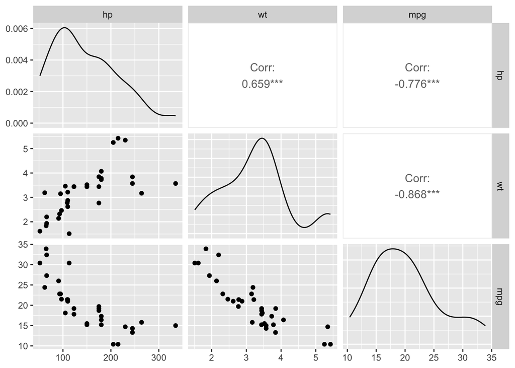

```r
# Check the relationships
d %>%
  dplyr::select(hp,wt,mpg) %>%
  GGally::ggpairs()
```

```r
# Check if the data has missing data points
md.pattern(d)
```

```
##  /\     /\
## {  `---'  }
## {  O   O  }
## ==>  V <==  No need for mice. This data set is completely observed.
##  \  \|/  /
##   `-----'
```

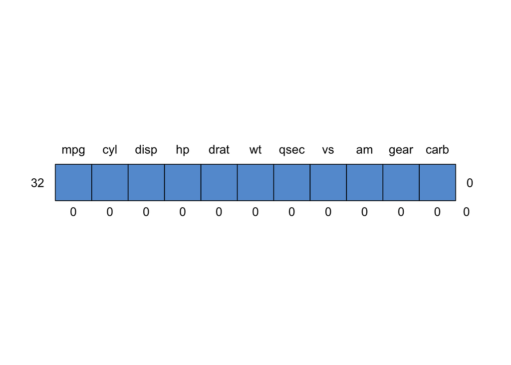

```
##    mpg cyl disp hp drat wt qsec vs am gear carb
## 32   1   1    1  1    1  1    1  1  1    1    1 0
##      0   0    0  0    0  0    0  0  0    0    0 0
```

#### To Fit a Mediation Model (to see if it supports the hypothesis [hp (x) → wt (m) → mpg (y)])

```r
med_model <- lm(wt ~ hp, data = d)
tot_model <- lm(mpg ~ hp + wt, data = d)
res <- mediate(model.m = med_model,
               model.y = tot_model,
               treat = 'hp',
               mediator = 'wt',
               boot = TRUE, sims = 100)
summary(res)
```

```
##
## Causal Mediation Analysis
##
## Nonparametric Bootstrap Confidence Intervals with the Percentile Method
##
##                Estimate 95% CI Lower 95% CI Upper p-value
## ACME            -0.0365      -0.0574        -0.02  <2e-16 ***
## ADE             -0.0318      -0.0504        -0.02  <2e-16 ***
## Total Effect    -0.0682      -0.1010        -0.04  <2e-16 ***
## Prop. Mediated   0.5343       0.3554         0.73  <2e-16 ***
## ---
## Signif. codes:  0 '***' 0.001 '**' 0.01 '*' 0.05 '.' 0.1 ' ' 1
##
## Sample Size Used: 32
##
##
## Simulations: 100
```

##### ACME = Average Causal Mediation Effects = INDIRECT EFFECT

*This is the X → Y mediated by M*

##### ADE = Average Direct Effect (M is HELD CONSTANT) = DIRECT EFFECT

*This is the effect of the independent variable on the dependent variable that does not occur through the mediator. It quantifies the direct relationship between the independent variable and the dependent variable, bypassing the mediator.*

##### Total Effect = Combined Influence

*It is essentially the total relationship between the independent variable and the dependent variable, **WITHOUT M**. Total Effect is the sum of the Average Direct Effect (ADE) and the Average Causal Mediation Effects (ACME).*

##### Prop. Mediated = Proportion Mediated

*It quantifies the fraction of the Total Effect that is due to the mediator. It quantifies the fraction of the Total Effect that is due to the mediator, or in other words, the portion of the Total Effect that is explained by the mediation process. It is calculated by dividing the Average Causal Mediation Effects (ACME) by the Total Effect.*

*This measure helps in understanding the relative importance or contribution of the mediator in explaining the relationship between the independent variable and the dependent variable. If the proportion is closer to 1, it suggests that a large part of the total effect operates through the mediator, while a proportion closer to 0 suggests that the mediator plays a minor role.*

#### Interpretation of the results:

##### ACME = Average Casual Mediation Effects = INDIRECT EFFECT

Estimate = -0.0365 means that the impact of Horse Power (X) to Mile Per Gallon (Y) through Wight (M) is *estimated, on average* - 0.0365 mpg, meaning one unit increase of HP (X) through the Wt (M) results in *an estimated reduction* of 0.0365 mpg (Y) on average.

##### ADE = Average Direct Effect (M is HELD CONSTANT) = DIRECT EFFECT

*An ADE of -0.0318 means that for every one-unit increase in HP (X), there is an estimated average decrease of 0.0318 units in mpg (Y), while accounting for (controlled for / holding constant) the mediator. This is a direct relationship between X and Y without considering the mediation effect of M.*

##### Total Effect = Combined Influence

##### Prop. Mediated: Proportion Mediated

An Estimate value of 0.5343 for the Proportion Mediated means that 53% of X and Y relationship is mediated by the Wight (M) of the vehicle.

The CI does not include zero, therefore, it is significantly significant, as supported by the corresponding p-value of less than 2e-16.

#### To Obtain Completely Standardized Indirect Effect (Upsilon)

```r
# Completely Standardized Indirect Effect
upsilon(x = d$hp,
        mediator = d$wt,
        dv = d$mpg, B = 50)
```

```
## Bootstrapping may take several minutes
##
```

```
##              Estimate 95% ordinary LCL 95% ordinary UCL
## Upsilon     0.1719908       0.06785279        0.4310114
## Adj Upsilon 0.1609993       0.06106123        0.4140383
```

##### 95% CI (LCL = Lower Confidence Limit | UCL = Upper Confidence Limit)

In simpler terms, there is evidence to believe that the influence of horse power on miles per gallon is significantly mediated by vehicle weight.

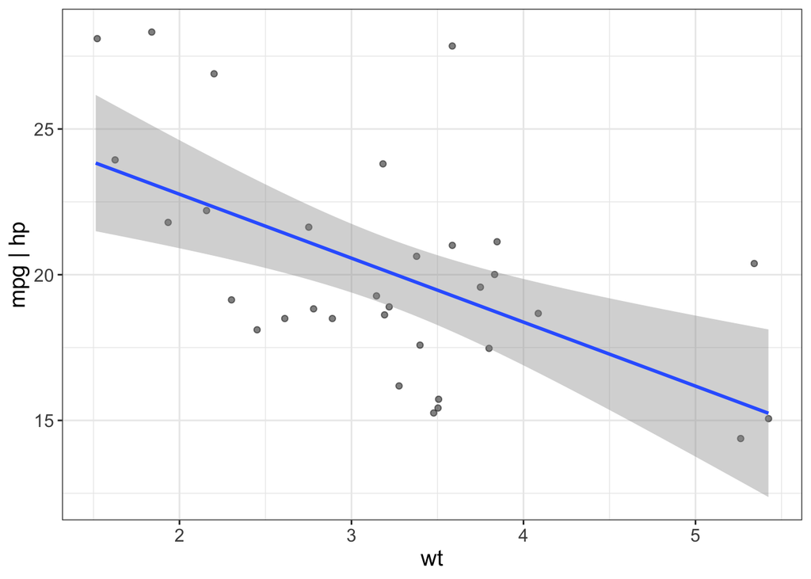

```r
# Plot
added.plot(mpg ~ hp + wt, data = d, method = "lm") # The wight is controlled for
```

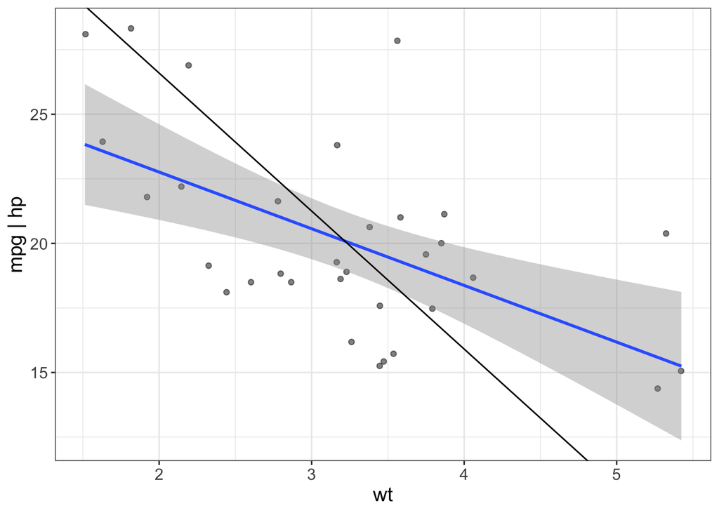

```r
mediate_plot(mpg ~ hp + wt, data = d) # This is the mediation model compared to the added plot
```